# Part I - (Dataset Exploration: Prosper Loan Dataset)

## Introduction

The prosper loan dataset is a financial dataset containing 113,937 loans with 81 variables on each loan. The dataset variables include things related to the loan, borrowers, lenders and interest rates. The table below lists and describes the variables of the dataset.

| Variable | Description |
| --- | --- |
| AmountDelinquent | Dollars delinquent at the time the credit profile was pulled. |
| AvailableBankcardCredit | The total available credit via bank card at the time the credit profile was pulled. |
| BankcardUtilization | The percentage of available revolving credit that is utilized at the time the credit profile was pulled. |
| BorrowerAPR | The Borrower’s Annual Percentage Rate (APR) for the loan. |
| BorrowerRate | The Borrower’s interest rate for this loan. |
| BorrowerState | The two letter abbreviation of the state of the address of the borrower at the time the Listing was created. |
| ClosedDate | Closed date is applicable for Cancelled, Completed, Chargedoff and Defaulted loan statuses. |
| CreditGrade | The Credit rating that was assigned at the time the listing went live. Applicable for listings pre-2009 period and will only be populated for those listings. |
| CreditScoreRangeLower | The lower value representing the range of the borrower’s credit score as provided by a consumer credit rating agency. |
| CreditScoreRangeUpper | The upper value representing the range of the borrower’s credit score as provided by a consumer credit rating agency. |
| CurrentCreditLines | Number of current credit lines at the time the credit profile was pulled. |
| CurrentDelinquencies | Number of accounts delinquent at the time the credit profile was pulled. |
| CurrentlyInGroup | Specifies whether or not the Borrower was in a group at the time the listing was created. |
| DateCreditPulled | The date the credit profile was pulled. |
| DebtToIncomeRatio | The debt to income ratio of the borrower at the time the credit profile was pulled. This value is Null if the debt to income ratio is not available. This value is capped at 10.01 (any debt to income r… |
| DelinquenciesLast7Years | Number of delinquencies in the past 7 years at the time the credit profile was pulled. |
| EmploymentStatus | The employment status of the borrower at the time they posted the listing. |
| EmploymentStatusDuration | The length in months of the employment status at the time the listing was created. |
| EstimatedEffectiveYield | Effective yield is equal to the borrower interest rate (i) minus the servicing fee rate, (ii) minus estimated uncollected interest on charge-offs, (iii) plus estimated collected late fees. Applicable … |
| EstimatedLoss | Estimated loss is the estimated principal loss on charge-offs. Applicable for loans originated after July 2009. |
| EstimatedReturn | The estimated return assigned to the listing at the time it was created. Estimated return is the difference between the Estimated Effective Yield and the Estimated Loss Rate. Applicable for loans orig… |
| FirstRecordedCreditLine | The date the first credit line was opened. |
| GroupKey | The Key of the group in which the Borrower is a member of. Value will be null if the borrower does not have a group affiliation. |
| IncomeRange | The income range of the borrower at the time the listing was created. |
| IncomeVerifiable | The borrower indicated they have the required documentation to support their income. |
| InquiriesLast6Months | Number of inquiries in the past six months at the time the credit profile was pulled. |
| InvestmentFromFriendsAmount | Dollar amount of investments that were made by friends. |
| InvestmentFromFriendsCount | Number of friends that made an investment in the loan. |
| Investors | The number of investors that funded the loan. |
| IsBorrowerHomeowner | A Borrower will be classified as a homowner if they have a mortgage on their credit profile or provide documentation confirming they are a homeowner. |

[output cut: 51 more lines]

Data dictionary gotten from: https://rstudio-pubs-static.s3.amazonaws.com/86324_ab1e2e2fa210452f80a1c6a1476d7a2a.html

## Preliminary Wrangling

### Data Gathering

```python
# import all packages and set plots to be embedded inline
import numpy as np
import pandas as pd
import matplotlib.pyplot as plt
import seaborn as sb

%matplotlib inline
```

```python
import warnings
warnings.filterwarnings('ignore')
warnings.simplefilter('ignore')
```

```python
import os
import requests
```

```python
# Gathering the data from the given url
url = 'https://s3.amazonaws.com/udacity-hosted-downloads/ud651/prosperLoanData.csv'
response = requests.get(url)
with open('prosperLoanData.csv', mode = 'wb') as file:
    file.write(response.content)

df_loan = pd.read_csv('prosperLoanData.csv', header=0)
```

### Assesing the dataset

> Moving on to exploring the dataset for any cleaning operations

```python
df_loan.shape
```

```
(113937, 81)
```

```python
df_loan.head()
```

|  | ListingKey | ListingNumber | ListingCreationDate | CreditGrade | Term | LoanStatus | ClosedDate | BorrowerAPR | BorrowerRate | LenderYield | ... | LP_ServiceFees | LP_CollectionFees | LP_GrossPrincipalLoss | LP_NetPrincipalLoss | LP_NonPrincipalRecoverypayments | PercentFunded | Recommendations | InvestmentFromFriendsCount | InvestmentFromFriendsAmount | Investors |
| --- | --- | --- | --- | --- | --- | --- | --- | --- | --- | --- | --- | --- | --- | --- | --- | --- | --- | --- | --- | --- | --- |
| 0 | 1021339766868145413AB3B | 193129 | 2007-08-26 19:09:29.263000000 | C | 36 | Completed | 2009-08-14 00:00:00 | 0.16516 | 0.1580 | 0.1380 | ... | -133.18 | 0.0 | 0.0 | 0.0 | 0.0 | 1.0 | 0 | 0 | 0.0 | 258 |
| 1 | 10273602499503308B223C1 | 1209647 | 2014-02-27 08:28:07.900000000 | NaN | 36 | Current | NaN | 0.12016 | 0.0920 | 0.0820 | ... | 0.00 | 0.0 | 0.0 | 0.0 | 0.0 | 1.0 | 0 | 0 | 0.0 | 1 |
| 2 | 0EE9337825851032864889A | 81716 | 2007-01-05 15:00:47.090000000 | HR | 36 | Completed | 2009-12-17 00:00:00 | 0.28269 | 0.2750 | 0.2400 | ... | -24.20 | 0.0 | 0.0 | 0.0 | 0.0 | 1.0 | 0 | 0 | 0.0 | 41 |
| 3 | 0EF5356002482715299901A | 658116 | 2012-10-22 11:02:35.010000000 | NaN | 36 | Current | NaN | 0.12528 | 0.0974 | 0.0874 | ... | -108.01 | 0.0 | 0.0 | 0.0 | 0.0 | 1.0 | 0 | 0 | 0.0 | 158 |
| 4 | 0F023589499656230C5E3E2 | 909464 | 2013-09-14 18:38:39.097000000 | NaN | 36 | Current | NaN | 0.24614 | 0.2085 | 0.1985 | ... | -60.27 | 0.0 | 0.0 | 0.0 | 0.0 | 1.0 | 0 | 0 | 0.0 | 20 |

5 rows × 81 columns

```python
df_loan.info()
```

```
<class 'pandas.core.frame.DataFrame'>
RangeIndex: 113937 entries, 0 to 113936
Data columns (total 81 columns):
ListingKey                             113937 non-null object
ListingNumber                          113937 non-null int64
ListingCreationDate                    113937 non-null object
CreditGrade                            28953 non-null object
Term                                   113937 non-null int64
LoanStatus                             113937 non-null object
ClosedDate                             55089 non-null object
BorrowerAPR                            113912 non-null float64
BorrowerRate                           113937 non-null float64
LenderYield                            113937 non-null float64
EstimatedEffectiveYield                84853 non-null float64
EstimatedLoss                          84853 non-null float64
EstimatedReturn                        84853 non-null float64
ProsperRating (numeric)                84853 non-null float64
ProsperRating (Alpha)                  84853 non-null object
ProsperScore                           84853 non-null float64
ListingCategory (numeric)              113937 non-null int64
BorrowerState                          108422 non-null object
Occupation                             110349 non-null object
EmploymentStatus                       111682 non-null object
EmploymentStatusDuration               106312 non-null float64
IsBorrowerHomeowner                    113937 non-null bool
CurrentlyInGroup                       113937 non-null bool
GroupKey                               13341 non-null object
DateCreditPulled                       113937 non-null object
CreditScoreRangeLower                  113346 non-null float64
CreditScoreRangeUpper                  113346 non-null float64
FirstRecordedCreditLine                113240 non-null object
CurrentCreditLines                     106333 non-null float64
OpenCreditLines                        106333 non-null float64
TotalCreditLinespast7years             113240 non-null float64
OpenRevolvingAccounts                  113937 non-null int64
OpenRevolvingMonthlyPayment            113937 non-null float64
InquiriesLast6Months                   113240 non-null float64
TotalInquiries                         112778 non-null float64
CurrentDelinquencies                   113240 non-null float64
AmountDelinquent                       106315 non-null float64
```

[output cut: 31 more lines]

```
LP_CustomerPayments                    113937 non-null float64
LP_CustomerPrincipalPayments           113937 non-null float64
LP_InterestandFees                     113937 non-null float64
LP_ServiceFees                         113937 non-null float64
LP_CollectionFees                      113937 non-null float64
LP_GrossPrincipalLoss                  113937 non-null float64
LP_NetPrincipalLoss                    113937 non-null float64
LP_NonPrincipalRecoverypayments        113937 non-null float64
PercentFunded                          113937 non-null float64
Recommendations                        113937 non-null int64
InvestmentFromFriendsCount             113937 non-null int64
InvestmentFromFriendsAmount            113937 non-null float64
Investors                              113937 non-null int64
dtypes: bool(3), float64(50), int64(11), object(17)
memory usage: 68.1+ MB
```

Going through the dataset, it is evident that not all the variables will be useful in my analysis, thus the dataset will be cleaned and reduced to enable faster analysis.

```python
# Making a copy of original dataset
loan_clean = df_loan.copy()
```

> A subset of the data will be created to enable the use of only the variables needed for the analysis.

```python
columns = ['ListingNumber', 'LoanStatus', 'LoanOriginationDate', 'EmploymentStatus', 'Occupation', 'BorrowerRate', 'BorrowerAPR',
           'EmploymentStatusDuration', 'IncomeRange', 'StatedMonthlyIncome', 'IncomeVerifiable', 'IsBorrowerHomeowner', 'ListingCategory (numeric)',
           'BorrowerState', 'MonthlyLoanPayment', 'OnTimeProsperPayments', 'ProsperPaymentsLessThanOneMonthLate',
           'ProsperPaymentsOneMonthPlusLate', 'CreditScoreRangeLower', 'CreditScoreRangeUpper',
           'DebtToIncomeRatio', 'LoanOriginalAmount', 'Term', 'ProsperScore']
loan_sub = loan_clean[columns]
```

### Assessing subset

> Further assesment can now be done for any cleaning operations regarding the subset.

```python
loan_sub.head()
```

|  | ListingNumber | LoanStatus | LoanOriginationDate | EmploymentStatus | Occupation | BorrowerRate | BorrowerAPR | EmploymentStatusDuration | IncomeRange | StatedMonthlyIncome | ... | MonthlyLoanPayment | OnTimeProsperPayments | ProsperPaymentsLessThanOneMonthLate | ProsperPaymentsOneMonthPlusLate | CreditScoreRangeLower | CreditScoreRangeUpper | DebtToIncomeRatio | LoanOriginalAmount | Term | ProsperScore |
| --- | --- | --- | --- | --- | --- | --- | --- | --- | --- | --- | --- | --- | --- | --- | --- | --- | --- | --- | --- | --- | --- |
| 0 | 193129 | Completed | 2007-09-12 00:00:00 | Self-employed | Other | 0.1580 | 0.16516 | 2.0 | $25,000-49,999 | 3083.333333 | ... | 330.43 | NaN | NaN | NaN | 640.0 | 659.0 | 0.17 | 9425 | 36 | NaN |
| 1 | 1209647 | Current | 2014-03-03 00:00:00 | Employed | Professional | 0.0920 | 0.12016 | 44.0 | $50,000-74,999 | 6125.000000 | ... | 318.93 | NaN | NaN | NaN | 680.0 | 699.0 | 0.18 | 10000 | 36 | 7.0 |
| 2 | 81716 | Completed | 2007-01-17 00:00:00 | Not available | Other | 0.2750 | 0.28269 | NaN | Not displayed | 2083.333333 | ... | 123.32 | NaN | NaN | NaN | 480.0 | 499.0 | 0.06 | 3001 | 36 | NaN |
| 3 | 658116 | Current | 2012-11-01 00:00:00 | Employed | Skilled Labor | 0.0974 | 0.12528 | 113.0 | $25,000-49,999 | 2875.000000 | ... | 321.45 | NaN | NaN | NaN | 800.0 | 819.0 | 0.15 | 10000 | 36 | 9.0 |
| 4 | 909464 | Current | 2013-09-20 00:00:00 | Employed | Executive | 0.2085 | 0.24614 | 44.0 | $100,000+ | 9583.333333 | ... | 563.97 | 11.0 | 0.0 | 0.0 | 680.0 | 699.0 | 0.26 | 15000 | 36 | 4.0 |

5 rows × 24 columns

```python
loan_sub.info()
```

```
<class 'pandas.core.frame.DataFrame'>
RangeIndex: 113937 entries, 0 to 113936
Data columns (total 24 columns):
ListingNumber                          113937 non-null int64
LoanStatus                             113937 non-null object
LoanOriginationDate                    113937 non-null object
EmploymentStatus                       111682 non-null object
Occupation                             110349 non-null object
BorrowerRate                           113937 non-null float64
BorrowerAPR                            113912 non-null float64
EmploymentStatusDuration               106312 non-null float64
IncomeRange                            113937 non-null object
StatedMonthlyIncome                    113937 non-null float64
IncomeVerifiable                       113937 non-null bool
IsBorrowerHomeowner                    113937 non-null bool
ListingCategory (numeric)              113937 non-null int64
BorrowerState                          108422 non-null object
MonthlyLoanPayment                     113937 non-null float64
OnTimeProsperPayments                  22085 non-null float64
ProsperPaymentsLessThanOneMonthLate    22085 non-null float64
ProsperPaymentsOneMonthPlusLate        22085 non-null float64
CreditScoreRangeLower                  113346 non-null float64
CreditScoreRangeUpper                  113346 non-null float64
DebtToIncomeRatio                      105383 non-null float64
LoanOriginalAmount                     113937 non-null int64
Term                                   113937 non-null int64
ProsperScore                           84853 non-null float64
dtypes: bool(2), float64(12), int64(4), object(6)
memory usage: 19.3+ MB
```

```python
loan_sub.nunique()
```

```
ListingNumber                          113066
LoanStatus                                 12
LoanOriginationDate                      1873
EmploymentStatus                            8
Occupation                                 67
BorrowerRate                             2294
BorrowerAPR                              6677
EmploymentStatusDuration                  605
IncomeRange                                 8
StatedMonthlyIncome                     13502
IncomeVerifiable                            2
IsBorrowerHomeowner                         2
ListingCategory (numeric)                  21
BorrowerState                              51
MonthlyLoanPayment                      23567
OnTimeProsperPayments                     127
ProsperPaymentsLessThanOneMonthLate        41
ProsperPaymentsOneMonthPlusLate            17
CreditScoreRangeLower                      26
CreditScoreRangeUpper                      26
DebtToIncomeRatio                        1207
LoanOriginalAmount                       2468
Term                                        3
ProsperScore                               11
dtype: int64
```

```python
loan_sub.describe()
```

|  | ListingNumber | BorrowerRate | BorrowerAPR | EmploymentStatusDuration | StatedMonthlyIncome | ListingCategory (numeric) | MonthlyLoanPayment | OnTimeProsperPayments | ProsperPaymentsLessThanOneMonthLate | ProsperPaymentsOneMonthPlusLate | CreditScoreRangeLower | CreditScoreRangeUpper | DebtToIncomeRatio | LoanOriginalAmount | Term | ProsperScore |
| --- | --- | --- | --- | --- | --- | --- | --- | --- | --- | --- | --- | --- | --- | --- | --- | --- |
| count | 1.139370e+05 | 113937.000000 | 113912.000000 | 106312.000000 | 1.139370e+05 | 113937.000000 | 113937.000000 | 22085.000000 | 22085.000000 | 22085.000000 | 113346.000000 | 113346.000000 | 105383.000000 | 113937.00000 | 113937.000000 | 84853.000000 |
| mean | 6.278857e+05 | 0.192764 | 0.218828 | 96.071582 | 5.608026e+03 | 2.774209 | 272.475783 | 22.271949 | 0.613629 | 0.048540 | 685.567731 | 704.567731 | 0.275947 | 8337.01385 | 40.830248 | 5.950067 |
| std | 3.280762e+05 | 0.074818 | 0.080364 | 94.480605 | 7.478497e+03 | 3.996797 | 192.697812 | 18.830425 | 2.446827 | 0.556285 | 66.458275 | 66.458275 | 0.551759 | 6245.80058 | 10.436212 | 2.376501 |
| min | 4.000000e+00 | 0.000000 | 0.006530 | 0.000000 | 0.000000e+00 | 0.000000 | 0.000000 | 0.000000 | 0.000000 | 0.000000 | 0.000000 | 19.000000 | 0.000000 | 1000.00000 | 12.000000 | 1.000000 |
| 25% | 4.009190e+05 | 0.134000 | 0.156290 | 26.000000 | 3.200333e+03 | 1.000000 | 131.620000 | 9.000000 | 0.000000 | 0.000000 | 660.000000 | 679.000000 | 0.140000 | 4000.00000 | 36.000000 | 4.000000 |
| 50% | 6.005540e+05 | 0.184000 | 0.209760 | 67.000000 | 4.666667e+03 | 1.000000 | 217.740000 | 15.000000 | 0.000000 | 0.000000 | 680.000000 | 699.000000 | 0.220000 | 6500.00000 | 36.000000 | 6.000000 |
| 75% | 8.926340e+05 | 0.250000 | 0.283810 | 137.000000 | 6.825000e+03 | 3.000000 | 371.580000 | 32.000000 | 0.000000 | 0.000000 | 720.000000 | 739.000000 | 0.320000 | 12000.00000 | 36.000000 | 8.000000 |
| max | 1.255725e+06 | 0.497500 | 0.512290 | 755.000000 | 1.750003e+06 | 20.000000 | 2251.510000 | 141.000000 | 42.000000 | 21.000000 | 880.000000 | 899.000000 | 10.010000 | 35000.00000 | 60.000000 | 11.000000 |

```python
loan_sub.isnull().sum()
```

```
ListingNumber                              0
LoanStatus                                 0
LoanOriginationDate                        0
EmploymentStatus                        2255
Occupation                              3588
BorrowerRate                               0
BorrowerAPR                               25
EmploymentStatusDuration                7625
IncomeRange                                0
StatedMonthlyIncome                        0
IncomeVerifiable                           0
IsBorrowerHomeowner                        0
ListingCategory (numeric)                  0
BorrowerState                           5515
MonthlyLoanPayment                         0
OnTimeProsperPayments                  91852
ProsperPaymentsLessThanOneMonthLate    91852
ProsperPaymentsOneMonthPlusLate        91852
CreditScoreRangeLower                    591
CreditScoreRangeUpper                    591
DebtToIncomeRatio                       8554
LoanOriginalAmount                         0
Term                                       0
ProsperScore                           29084
dtype: int64
```

```python
loan_sub['ListingNumber'].duplicated().sum()
```

```
871
```

#### Issues observed

The major issues noticed are:

1. Duplicated ListingNumber enteries.
2. wrong data types for ListingNumber and LoanOriginationDate

### Data Cleaning

#### 1. Duplicated records

Further assesing the dataset to make sure the duplicates are actually duplicated and not just mistakes.

```python
# Checking the duplicates using more than one column.
duplicateRows = loan_sub[loan_sub.duplicated(['ListingNumber', 'Occupation', 'BorrowerState'])]
```

```python
duplicateRows
```

|  | ListingNumber | LoanStatus | LoanOriginationDate | EmploymentStatus | Occupation | BorrowerRate | BorrowerAPR | EmploymentStatusDuration | IncomeRange | StatedMonthlyIncome | ... | MonthlyLoanPayment | OnTimeProsperPayments | ProsperPaymentsLessThanOneMonthLate | ProsperPaymentsOneMonthPlusLate | CreditScoreRangeLower | CreditScoreRangeUpper | DebtToIncomeRatio | LoanOriginalAmount | Term | ProsperScore |
| --- | --- | --- | --- | --- | --- | --- | --- | --- | --- | --- | --- | --- | --- | --- | --- | --- | --- | --- | --- | --- | --- |
| 9 | 1023355 | Current | 2013-12-12 00:00:00 | Employed | Food Service | 0.0629 | 0.07620 | 269.0 | $25,000-49,999 | 3333.333333 | ... | 305.54 | NaN | NaN | NaN | 820.0 | 839.0 | 0.25 | 10000 | 36 | 11.0 |
| 999 | 1055932 | Current | 2014-02-12 00:00:00 | Employed | Other | 0.1535 | 0.17710 | 100.0 | $25,000-49,999 | 3750.000000 | ... | 239.74 | NaN | NaN | NaN | 760.0 | 779.0 | 0.35 | 10000 | 60 | 7.0 |
| 2539 | 1097584 | Current | 2014-03-11 00:00:00 | Employed | Police Officer/Correction Officer | 0.1224 | 0.14528 | 107.0 | $100,000+ | 10833.333333 | ... | 782.81 | NaN | NaN | NaN | 720.0 | 739.0 | 0.18 | 35000 | 60 | 10.0 |
| 4942 | 927246 | Current | 2013-10-01 00:00:00 | Employed | Laborer | 0.3134 | 0.35356 | 336.0 | $50,000-74,999 | 4583.333333 | ... | 172.76 | NaN | NaN | NaN | 640.0 | 659.0 | 0.07 | 4000 | 36 | 2.0 |
| 5812 | 920397 | Current | 2013-11-14 00:00:00 | Other | NaN | 0.2045 | 0.24205 | 0.0 | $50,000-74,999 | 4166.666667 | ... | 560.90 | NaN | NaN | NaN | 700.0 | 719.0 | 0.62 | 15000 | 36 | 4.0 |
| 5971 | 894748 | Current | 2013-10-21 00:00:00 | Employed | Civil Service | 0.1620 | 0.18555 | 325.0 | $25,000-49,999 | 3750.000000 | ... | 244.24 | NaN | NaN | NaN | 680.0 | 699.0 | 0.26 | 10000 | 60 | 4.0 |
| 6385 | 1066466 | Current | 2014-01-21 00:00:00 | Employed | Professional | 0.0879 | 0.11563 | 27.0 | $100,000+ | 14166.666667 | ... | 317.02 | 28.0 | 1.0 | 0.0 | 700.0 | 719.0 | 0.25 | 10000 | 36 | 10.0 |
| 7415 | 875616 | Current | 2013-11-01 00:00:00 | Employed | Clerical | 0.2209 | 0.24589 | 23.0 | $50,000-74,999 | 5416.666667 | ... | 276.70 | NaN | NaN | NaN | 680.0 | 699.0 | 0.25 | 10000 | 60 | 3.0 |
| 7538 | 969821 | Current | 2013-12-23 00:00:00 | Employed | Other | 0.1685 | 0.20524 | 95.0 | $100,000+ | 12916.666667 | ... | 177.89 | NaN | NaN | NaN | 680.0 | 699.0 | 0.18 | 5000 | 36 | 4.0 |
| 7555 | 970570 | Current | 2013-12-18 00:00:00 | Self-employed | Construction | 0.0990 | 0.12691 | 107.0 | $25,000-49,999 | 3666.666667 | ... | 322.20 | 35.0 | 0.0 | 0.0 | 700.0 | 719.0 | NaN | 10000 | 36 | 8.0 |
| 8683 | 1047993 | Current | 2014-01-31 00:00:00 | Employed | Accountant/CPA | 0.1685 | 0.20524 | 49.0 | $25,000-49,999 | 2114.916667 | ... | 142.31 | 1.0 | 0.0 | 0.0 | 660.0 | 679.0 | 0.48 | 4000 | 36 | 10.0 |
| 8925 | 1138422 | Current | 2014-03-10 00:00:00 | Employed | Executive | 0.1920 | 0.22966 | 229.0 | $75,000-99,999 | 7083.333333 | ... | 551.36 | 23.0 | 1.0 | 0.0 | 720.0 | 739.0 | 0.57 | 15000 | 36 | 5.0 |
| 9102 | 1100572 | Current | 2014-02-19 00:00:00 | Employed | Other | 0.2394 | 0.27817 | 43.0 | $25,000-49,999 | 2750.000000 | ... | 156.81 | 18.0 | 0.0 | 0.0 | 640.0 | 659.0 | 0.20 | 4000 | 36 | 1.0 |
| 9281 | 1057901 | Current | 2014-01-22 00:00:00 | Employed | Professional | 0.3059 | 0.34588 | 29.0 | $25,000-49,999 | 2500.000000 | ... | 85.55 | NaN | NaN | NaN | 640.0 | 659.0 | 0.33 | 2000 | 36 | 3.0 |
| 10036 | 1101199 | Current | 2014-01-15 00:00:00 | Employed | Tradesman - Electrician | 0.1535 | 0.18990 | 171.0 | $75,000-99,999 | 7083.333333 | ... | 522.55 | NaN | NaN | NaN | 660.0 | 679.0 | 0.24 | 15000 | 36 | 4.0 |
| 10401 | 898052 | Current | 2013-09-18 00:00:00 | Employed | Nurse (RN) | 0.2566 | 0.29537 | 75.0 | $75,000-99,999 | 6406.666667 | ... | 160.44 | NaN | NaN | NaN | 680.0 | 699.0 | 0.16 | 4000 | 36 | 7.0 |
| 10467 | 890514 | Current | 2013-11-04 00:00:00 | Employed | Administrative Assistant | 0.1660 | 0.20268 | 284.0 | $75,000-99,999 | 7666.666667 | ... | 106.36 | NaN | NaN | NaN | 660.0 | 679.0 | 0.24 | 3000 | 36 | 7.0 |
| 11635 | 1069928 | Current | 2014-02-18 00:00:00 | Employed | Teacher | 0.1314 | 0.15449 | 42.0 | $50,000-74,999 | 4166.666667 | ... | 45.65 | NaN | NaN | NaN | 740.0 | 759.0 | 0.24 | 2000 | 60 | 8.0 |
| 11889 | 1063352 | Current | 2014-01-10 00:00:00 | Employed | Sales - Retail | 0.1239 | 0.15223 | 75.0 | $25,000-49,999 | 3916.666667 | ... | 292.26 | NaN | NaN | NaN | 720.0 | 739.0 | 0.26 | 8750 | 36 | 5.0 |
| 11979 | 900913 | Current | 2013-11-08 00:00:00 | Employed | Accountant/CPA | 0.1249 | 0.14760 | 32.0 | $50,000-74,999 | 5416.666667 | ... | 449.86 | 31.0 | 0.0 | 0.0 | 700.0 | 719.0 | 0.29 | 20000 | 60 | 10.0 |
| 12379 | 1116810 | Current | 2014-01-13 00:00:00 | Employed | Other | 0.1765 | 0.20040 | 41.0 | $50,000-74,999 | 6166.666667 | ... | 163.82 | NaN | NaN | NaN | 660.0 | 679.0 | 0.16 | 6500 | 60 | 5.0 |
| 12595 | 877625 | Current | 2013-10-10 00:00:00 | Employed | Other | 0.1485 | 0.18479 | 201.0 | $25,000-49,999 | 2791.666667 | ... | 172.96 | NaN | NaN | NaN | 680.0 | 699.0 | 0.40 | 5000 | 36 | 8.0 |
| 12694 | 1114591 | Current | 2014-02-04 00:00:00 | Employed | Sales - Commission | 0.1355 | 0.15844 | 43.0 | $75,000-99,999 | 6666.666667 | ... | 575.89 | NaN | NaN | NaN | 720.0 | 739.0 | 0.30 | 25000 | 60 | 4.0 |
| 12780 | 1114591 | Current | 2014-02-04 00:00:00 | Employed | Sales - Commission | 0.1355 | 0.15844 | 43.0 | $75,000-99,999 | 6666.666667 | ... | 575.89 | NaN | NaN | NaN | 720.0 | 739.0 | 0.30 | 25000 | 60 | 7.0 |
| 12956 | 925803 | Current | 2013-11-15 00:00:00 | Employed | Professional | 0.1980 | 0.23540 | 173.0 | $50,000-74,999 | 4666.666667 | ... | 296.49 | 52.0 | 0.0 | 0.0 | 660.0 | 679.0 | 0.33 | 8000 | 36 | 1.0 |
| 13210 | 1027003 | Current | 2014-01-24 00:00:00 | Self-employed | Other | 0.1189 | 0.14714 | 41.0 | $25,000-49,999 | 3033.333333 | ... | 331.62 | 28.0 | 0.0 | 0.0 | 680.0 | 699.0 | NaN | 10000 | 36 | 8.0 |
| 13322 | 1111486 | Current | 2014-03-07 00:00:00 | Employed | Analyst | 0.1199 | 0.14853 | 109.0 | $75,000-99,999 | 7798.333333 | ... | 531.35 | NaN | NaN | NaN | 700.0 | 719.0 | 0.23 | 16000 | 36 | 6.0 |
| 13445 | 1138731 | Current | 2014-02-26 00:00:00 | Other | NaN | 0.2394 | 0.26514 | 1.0 | $1-24,999 | 976.000000 | ... | 114.93 | NaN | NaN | NaN | 660.0 | 679.0 | 0.23 | 4000 | 60 | 3.0 |
| 14062 | 1077775 | Current | 2014-01-08 00:00:00 | Self-employed | Realtor | 0.1585 | 0.19501 | 21.0 | $25,000-49,999 | 3750.000000 | ... | 350.83 | NaN | NaN | NaN | 660.0 | 679.0 | NaN | 10000 | 36 | 7.0 |
| 14071 | 898757 | Current | 2013-10-02 00:00:00 | Employed | Civil Service | 0.1950 | 0.23233 | 88.0 | $25,000-49,999 | 2500.000000 | ... | 147.64 | 34.0 | 1.0 | 0.0 | 660.0 | 679.0 | 0.21 | 4000 | 36 | 5.0 |
| ... | ... | ... | ... | ... | ... | ... | ... | ... | ... | ... | ... | ... | ... | ... | ... | ... | ... | ... | ... | ... | ... |
| 111815 | 1128831 | Current | 2014-02-14 00:00:00 | Employed | Executive | 0.1840 | 0.20833 | 15.0 | $50,000-74,999 | 5416.666667 | ... | 332.95 | NaN | NaN | NaN | 680.0 | 699.0 | 0.23 | 13000 | 60 | 6.0 |
| 111839 | 1048512 | Current | 2013-12-11 00:00:00 | Employed | Medical Technician | 0.1465 | 0.16969 | 72.0 | $75,000-99,999 | 6250.000000 | ... | 472.13 | NaN | NaN | NaN | 660.0 | 679.0 | 0.11 | 20000 | 60 | 8.0 |
| 111850 | 959620 | Current | 2014-01-13 00:00:00 | Employed | Professional | 0.0879 | 0.11563 | 227.0 | $75,000-99,999 | 7500.000000 | ... | 412.13 | NaN | NaN | NaN | 740.0 | 759.0 | 0.23 | 13000 | 36 | 4.0 |
| 111860 | 996931 | Current | 2013-12-16 00:00:00 | Employed | Professional | 0.1725 | 0.20933 | 57.0 | $50,000-74,999 | 5358.166667 | ... | 447.22 | NaN | NaN | NaN | 680.0 | 699.0 | 0.41 | 12500 | 36 | 1.0 |
| 111890 | 827053 | Current | 2013-09-17 00:00:00 | Employed | Construction | 0.1474 | 0.17061 | 145.0 | $50,000-74,999 | 4166.666667 | ... | 354.81 | NaN | NaN | NaN | 780.0 | 799.0 | 0.29 | 15000 | 60 | 11.0 |
| 111991 | 916391 | Current | 2013-11-19 00:00:00 | Employed | Retail Management | 0.1550 | 0.19144 | 72.0 | $50,000-74,999 | 5000.000000 | ... | 261.83 | NaN | NaN | NaN | 700.0 | 719.0 | 0.24 | 7500 | 36 | 6.0 |
| 111992 | 978862 | Current | 2013-11-25 00:00:00 | Employed | Skilled Labor | 0.1550 | 0.17839 | 319.0 | $50,000-74,999 | 4583.333333 | ... | 168.37 | NaN | NaN | NaN | 680.0 | 699.0 | 0.15 | 7000 | 60 | 8.0 |
| 112216 | 1184373 | Current | 2014-02-10 00:00:00 | Employed | Other | 0.1314 | 0.16732 | 7.0 | $25,000-49,999 | 3333.333333 | ... | 253.21 | NaN | NaN | NaN | 680.0 | 699.0 | 0.23 | 7500 | 36 | 5.0 |
| 112413 | 1188953 | Current | 2014-02-12 00:00:00 | Employed | Professional | 0.1940 | 0.21858 | 26.0 | $50,000-74,999 | 5833.333333 | ... | 104.64 | 26.0 | 0.0 | 0.0 | 680.0 | 699.0 | 0.41 | 4000 | 60 | 8.0 |
| 112495 | 969859 | Current | 2013-12-09 00:00:00 | Employed | Computer Programmer | 0.1189 | 0.14714 | 42.0 | $100,000+ | 11000.000000 | ... | 431.10 | NaN | NaN | NaN | 680.0 | 699.0 | 0.18 | 13000 | 36 | 10.0 |
| 112536 | 880829 | Current | 2013-10-08 00:00:00 | Employed | Professional | 0.1159 | 0.14409 | 108.0 | $50,000-74,999 | 5166.666667 | ... | 330.19 | NaN | NaN | NaN | 660.0 | 679.0 | 0.25 | 10000 | 36 | 4.0 |
| 112603 | 1054075 | Current | 2014-01-31 00:00:00 | Employed | Teacher | 0.2010 | 0.22549 | 41.0 | $25,000-49,999 | 3750.000000 | ... | 265.50 | NaN | NaN | NaN | 720.0 | 739.0 | 0.37 | 10000 | 60 | 1.0 |
| 112854 | 1221869 | Current | 2014-03-05 00:00:00 | Other | NaN | 0.1745 | 0.21176 | 23.0 | $25,000-49,999 | 2500.000000 | ... | 143.51 | NaN | NaN | NaN | 700.0 | 719.0 | 0.42 | 4000 | 36 | 4.0 |
| 112882 | 1092778 | Current | 2014-01-28 00:00:00 | Employed | Police Officer/Correction Officer | 0.1905 | 0.21474 | 22.0 | $25,000-49,999 | 3363.250000 | ... | 259.68 | 2.0 | 0.0 | 0.0 | 680.0 | 699.0 | 0.50 | 10000 | 60 | 9.0 |
| 112919 | 1060784 | Current | 2014-02-12 00:00:00 | Other | NaN | 0.1685 | 0.19221 | 0.0 | $50,000-74,999 | 4583.333333 | ... | 371.58 | NaN | NaN | NaN | 680.0 | 699.0 | 0.36 | 15000 | 60 | 4.0 |
| 112924 | 1088357 | Current | 2014-02-10 00:00:00 | Employed | Other | 0.1465 | 0.18275 | 138.0 | $25,000-49,999 | 2500.000000 | ... | 137.98 | NaN | NaN | NaN | 680.0 | 699.0 | 0.19 | 4000 | 36 | 4.0 |
| 112935 | 1091759 | Current | 2014-01-16 00:00:00 | Employed | Other | 0.1840 | 0.22108 | 84.0 | $50,000-74,999 | 5000.000000 | ... | 545.30 | NaN | NaN | NaN | 720.0 | 739.0 | 0.57 | 15000 | 36 | 2.0 |
| 113025 | 1166367 | Current | 2014-02-12 00:00:00 | Other | NaN | 0.2080 | 0.23293 | 0.0 | $1-24,999 | 1166.666667 | ... | 80.82 | NaN | NaN | NaN | 640.0 | 659.0 | 0.29 | 3000 | 60 | 7.0 |
| 113136 | 955489 | Current | 2013-12-27 00:00:00 | Employed | Executive | 0.1189 | 0.14714 | 170.0 | $100,000+ | 14166.666667 | ... | 829.04 | NaN | NaN | NaN | 700.0 | 719.0 | 0.18 | 25000 | 36 | 7.0 |
| 113144 | 942150 | Current | 2013-11-22 00:00:00 | Employed | Civil Service | 0.1249 | 0.14760 | 271.0 | $100,000+ | 8583.333333 | ... | 337.39 | 15.0 | 0.0 | 0.0 | 780.0 | 799.0 | 0.31 | 15000 | 60 | 8.0 |
| 113218 | 1197011 | Current | 2014-02-27 00:00:00 | Employed | Professional | 0.1119 | 0.14039 | 115.0 | $100,000+ | 10083.333333 | ... | 492.43 | NaN | NaN | NaN | 780.0 | 799.0 | 0.34 | 15000 | 36 | 1.0 |
| 113356 | 983181 | Current | 2013-10-22 00:00:00 | Employed | Professional | 0.2225 | 0.26047 | 260.0 | $25,000-49,999 | 3666.666667 | ... | 383.20 | NaN | NaN | NaN | 700.0 | 719.0 | 0.54 | 10000 | 36 | 4.0 |
| 113386 | 1163997 | Current | 2014-02-18 00:00:00 | Employed | Teacher | 0.1139 | 0.14243 | 18.0 | $25,000-49,999 | 3333.333333 | ... | 263.39 | NaN | NaN | NaN | 680.0 | 699.0 | 0.21 | 8000 | 36 | 5.0 |
| 113431 | 1071926 | Current | 2014-01-29 00:00:00 | Employed | Laborer | 0.1685 | 0.20524 | 156.0 | $50,000-74,999 | 4166.666667 | ... | 355.78 | NaN | NaN | NaN | 640.0 | 659.0 | 0.14 | 10000 | 36 | 7.0 |
| 113468 | 933395 | Current | 2013-10-02 00:00:00 | Employed | Tradesman - Mechanic | 0.2015 | 0.22601 | 23.0 | $25,000-49,999 | 3333.333333 | ... | 132.89 | NaN | NaN | NaN | 680.0 | 699.0 | 0.29 | 5000 | 60 | 4.0 |
| 113548 | 1158474 | Current | 2014-03-04 00:00:00 | Employed | Other | 0.1960 | 0.22063 | 0.0 | $75,000-99,999 | 7666.666667 | ... | 367.81 | NaN | NaN | NaN | 700.0 | 719.0 | 0.15 | 14000 | 60 | 8.0 |
| 113636 | 904020 | Current | 2013-11-12 00:00:00 | Other | NaN | 0.1760 | 0.21290 | 0.0 | $25,000-49,999 | 2500.000000 | ... | 143.81 | NaN | NaN | NaN | 680.0 | 699.0 | 0.20 | 4000 | 36 | 6.0 |
| 113733 | 1002326 | Current | 2013-11-13 00:00:00 | Employed | Skilled Labor | 0.1819 | 0.20593 | 280.0 | $50,000-74,999 | 4583.333333 | ... | 254.97 | NaN | NaN | NaN | 720.0 | 739.0 | 0.42 | 10000 | 60 | 8.0 |
| 113773 | 1056749 | Current | 2013-12-23 00:00:00 | Employed | Other | 0.1274 | 0.16324 | 26.0 | $25,000-49,999 | 2720.833333 | ... | 335.69 | NaN | NaN | NaN | 700.0 | 719.0 | 0.36 | 10000 | 36 | 6.0 |
| 113863 | 928893 | Current | 2013-11-22 00:00:00 | Employed | Principal | 0.0990 | 0.12691 | 230.0 | $25,000-49,999 | 3333.333333 | ... | 209.43 | NaN | NaN | NaN | 760.0 | 779.0 | 0.18 | 6500 | 36 | 6.0 |

871 rows × 24 columns

> Listing out the duplicated rows to do a manual assessment.

```python
loan_sub[loan_sub['ListingNumber'].isin(duplicateRows.ListingNumber)].sort_values(by=['ListingNumber'])
```

|  | ListingNumber | LoanStatus | LoanOriginationDate | EmploymentStatus | Occupation | BorrowerRate | BorrowerAPR | EmploymentStatusDuration | IncomeRange | StatedMonthlyIncome | ... | MonthlyLoanPayment | OnTimeProsperPayments | ProsperPaymentsLessThanOneMonthLate | ProsperPaymentsOneMonthPlusLate | CreditScoreRangeLower | CreditScoreRangeUpper | DebtToIncomeRatio | LoanOriginalAmount | Term | ProsperScore |
| --- | --- | --- | --- | --- | --- | --- | --- | --- | --- | --- | --- | --- | --- | --- | --- | --- | --- | --- | --- | --- | --- |
| 33649 | 701942 | Current | 2013-09-25 00:00:00 | Employed | Engineer - Mechanical | 0.0605 | 0.06726 | 73.0 | $50,000-74,999 | 4583.333333 | ... | 456.67 | 2.0 | 0.0 | 0.0 | 800.0 | 819.0 | 0.19 | 15000 | 36 | 10.0 |
| 32664 | 701942 | Current | 2013-09-25 00:00:00 | Employed | Engineer - Mechanical | 0.0605 | 0.06726 | 73.0 | $50,000-74,999 | 4583.333333 | ... | 456.67 | 2.0 | 0.0 | 0.0 | 800.0 | 819.0 | 0.19 | 15000 | 36 | 11.0 |
| 16311 | 786407 | Current | 2013-09-24 00:00:00 | Other | Other | 0.2155 | 0.24036 | 37.0 | $50,000-74,999 | 6000.000000 | ... | 410.45 | NaN | NaN | NaN | 680.0 | 699.0 | 0.23 | 15000 | 60 | 6.0 |
| 87265 | 786407 | Current | 2013-09-24 00:00:00 | Other | Other | 0.2155 | 0.24036 | 37.0 | $50,000-74,999 | 6000.000000 | ... | 410.45 | NaN | NaN | NaN | 680.0 | 699.0 | 0.23 | 15000 | 60 | 4.0 |
| 52546 | 812537 | Current | 2013-10-07 00:00:00 | Employed | Retail Management | 0.1399 | 0.16294 | 220.0 | $75,000-99,999 | 6916.666667 | ... | 372.21 | NaN | NaN | NaN | 760.0 | 779.0 | 0.20 | 16000 | 60 | 4.0 |
| 8693 | 812537 | Current | 2013-10-07 00:00:00 | Employed | Retail Management | 0.1399 | 0.16294 | 220.0 | $75,000-99,999 | 6916.666667 | ... | 372.21 | NaN | NaN | NaN | 760.0 | 779.0 | 0.20 | 16000 | 60 | 6.0 |
| 86576 | 815571 | Current | 2013-11-07 00:00:00 | Employed | Professional | 0.1050 | 0.13301 | 32.0 | $25,000-49,999 | 3333.333333 | ... | 325.02 | NaN | NaN | NaN | 740.0 | 759.0 | 0.35 | 10000 | 36 | 10.0 |
| 25504 | 815571 | Current | 2013-11-07 00:00:00 | Employed | Professional | 0.1050 | 0.13301 | 32.0 | $25,000-49,999 | 3333.333333 | ... | 325.02 | NaN | NaN | NaN | 740.0 | 759.0 | 0.35 | 10000 | 36 | 6.0 |
| 64448 | 822680 | Current | 2013-11-20 00:00:00 | Employed | Sales - Retail | 0.1800 | 0.21699 | 94.0 | $25,000-49,999 | 2458.333333 | ... | 72.30 | 11.0 | 0.0 | 0.0 | 680.0 | 699.0 | 0.30 | 2000 | 36 | 1.0 |
| 88484 | 822680 | Current | 2013-11-20 00:00:00 | Employed | Sales - Retail | 0.1800 | 0.21699 | 94.0 | $25,000-49,999 | 2458.333333 | ... | 72.30 | 11.0 | 0.0 | 0.0 | 680.0 | 699.0 | 0.30 | 2000 | 36 | 4.0 |
| 111890 | 827053 | Current | 2013-09-17 00:00:00 | Employed | Construction | 0.1474 | 0.17061 | 145.0 | $50,000-74,999 | 4166.666667 | ... | 354.81 | NaN | NaN | NaN | 780.0 | 799.0 | 0.29 | 15000 | 60 | 11.0 |
| 21559 | 827053 | Current | 2013-09-17 00:00:00 | Employed | Construction | 0.1474 | 0.17061 | 145.0 | $50,000-74,999 | 4166.666667 | ... | 354.81 | NaN | NaN | NaN | 780.0 | 799.0 | 0.29 | 15000 | 60 | 6.0 |
| 59216 | 836614 | Current | 2013-09-26 00:00:00 | Employed | Professional | 0.1249 | 0.15324 | 55.0 | $75,000-99,999 | 7750.000000 | ... | 518.46 | NaN | NaN | NaN | 700.0 | 719.0 | 0.22 | 15500 | 36 | 5.0 |
| 24355 | 836614 | Current | 2013-09-26 00:00:00 | Employed | Professional | 0.1249 | 0.15324 | 55.0 | $75,000-99,999 | 7750.000000 | ... | 518.46 | NaN | NaN | NaN | 700.0 | 719.0 | 0.22 | 15500 | 36 | 7.0 |
| 65623 | 843648 | Current | 2013-09-30 00:00:00 | Employed | Teacher | 0.0819 | 0.09534 | 84.0 | $75,000-99,999 | 6666.666667 | ... | 408.51 | NaN | NaN | NaN | 740.0 | 759.0 | 0.22 | 13000 | 36 | 10.0 |
| 65622 | 843648 | Current | 2013-09-30 00:00:00 | Employed | Teacher | 0.0819 | 0.09534 | 84.0 | $75,000-99,999 | 6666.666667 | ... | 408.51 | NaN | NaN | NaN | 740.0 | 759.0 | 0.22 | 13000 | 36 | 8.0 |
| 28358 | 844220 | Current | 2013-09-27 00:00:00 | Employed | Computer Programmer | 0.1620 | 0.18555 | 271.0 | $100,000+ | 12416.666667 | ... | 610.61 | NaN | NaN | NaN | 680.0 | 699.0 | 0.28 | 25000 | 60 | 6.0 |
| 3520 | 844220 | Current | 2013-09-27 00:00:00 | Employed | Computer Programmer | 0.1620 | 0.18555 | 271.0 | $100,000+ | 12416.666667 | ... | 610.61 | NaN | NaN | NaN | 680.0 | 699.0 | 0.28 | 25000 | 60 | 4.0 |
| 2206 | 851219 | Current | 2013-10-01 00:00:00 | Employed | Other | 0.1760 | 0.21290 | 60.0 | $25,000-49,999 | 3166.666667 | ... | 143.81 | NaN | NaN | NaN | 720.0 | 739.0 | 0.50 | 4000 | 36 | 2.0 |
| 54248 | 851219 | Current | 2013-10-01 00:00:00 | Employed | Other | 0.1760 | 0.21290 | 60.0 | $25,000-49,999 | 3166.666667 | ... | 143.81 | NaN | NaN | NaN | 720.0 | 739.0 | 0.50 | 4000 | 36 | 5.0 |
| 109074 | 852758 | Current | 2013-09-26 00:00:00 | Employed | Food Service Management | 0.1730 | 0.19681 | 418.0 | $50,000-74,999 | 5654.000000 | ... | 387.72 | 15.0 | 0.0 | 0.0 | 680.0 | 699.0 | 0.22 | 15500 | 60 | 10.0 |
| 85821 | 852758 | Current | 2013-09-26 00:00:00 | Employed | Food Service Management | 0.1730 | 0.19681 | 418.0 | $50,000-74,999 | 5654.000000 | ... | 387.72 | 15.0 | 0.0 | 0.0 | 680.0 | 699.0 | 0.22 | 15500 | 60 | 8.0 |
| 35457 | 853665 | Current | 2013-10-04 00:00:00 | Employed | Military Officer | 0.2549 | 0.29363 | 195.0 | $100,000+ | 8666.666667 | ... | 160.08 | NaN | NaN | NaN | 640.0 | 659.0 | 0.09 | 4000 | 36 | 5.0 |
| 54840 | 853665 | Current | 2013-10-04 00:00:00 | Employed | Military Officer | 0.2549 | 0.29363 | 195.0 | $100,000+ | 8666.666667 | ... | 160.08 | NaN | NaN | NaN | 640.0 | 659.0 | 0.09 | 4000 | 36 | 4.0 |
| 13855 | 855637 | Current | 2013-10-24 00:00:00 | Employed | Professional | 0.1099 | 0.13799 | 6.0 | $100,000+ | 12500.000000 | ... | 818.35 | NaN | NaN | NaN | 740.0 | 759.0 | 0.08 | 25000 | 36 | 11.0 |
| 39598 | 855637 | Current | 2013-10-24 00:00:00 | Employed | Professional | 0.1099 | 0.13799 | 6.0 | $100,000+ | 12500.000000 | ... | 818.35 | NaN | NaN | NaN | 740.0 | 759.0 | 0.08 | 25000 | 36 | 10.0 |
| 43737 | 857826 | Current | 2013-11-06 00:00:00 | Employed | Food Service Management | 0.1550 | 0.17839 | 54.0 | $25,000-49,999 | 3333.333333 | ... | 240.53 | NaN | NaN | NaN | 680.0 | 699.0 | 0.21 | 10000 | 60 | 4.0 |
| 32805 | 857826 | Current | 2013-11-06 00:00:00 | Employed | Food Service Management | 0.1550 | 0.17839 | 54.0 | $25,000-49,999 | 3333.333333 | ... | 240.53 | NaN | NaN | NaN | 680.0 | 699.0 | 0.21 | 10000 | 60 | 8.0 |
| 3573 | 858364 | Current | 2013-09-16 00:00:00 | Employed | Retail Management | 0.1950 | 0.21935 | 50.0 | $75,000-99,999 | 6833.333333 | ... | 301.49 | NaN | NaN | NaN | 720.0 | 739.0 | 0.30 | 11500 | 60 | 7.0 |
| 73145 | 858364 | Current | 2013-09-16 00:00:00 | Employed | Retail Management | 0.1950 | 0.21935 | 50.0 | $75,000-99,999 | 6833.333333 | ... | 301.49 | NaN | NaN | NaN | 720.0 | 739.0 | 0.30 | 11500 | 60 | 4.0 |
| ... | ... | ... | ... | ... | ... | ... | ... | ... | ... | ... | ... | ... | ... | ... | ... | ... | ... | ... | ... | ... | ... |
| 71468 | 1220004 | Current | 2014-02-25 00:00:00 | Employed | Teacher | 0.1099 | 0.13250 | 67.0 | $50,000-74,999 | 5916.666667 | ... | 326.06 | NaN | NaN | NaN | 800.0 | 819.0 | 0.24 | 15000 | 60 | 5.0 |
| 96992 | 1220004 | Current | 2014-02-25 00:00:00 | Employed | Teacher | 0.1099 | 0.13250 | 67.0 | $50,000-74,999 | 5916.666667 | ... | 326.06 | NaN | NaN | NaN | 800.0 | 819.0 | 0.24 | 15000 | 60 | 4.0 |
| 37384 | 1220787 | Current | 2014-03-10 00:00:00 | Other | NaN | 0.1159 | 0.14446 | 0.0 | $75,000-99,999 | 7583.333333 | ... | 165.09 | NaN | NaN | NaN | 660.0 | 679.0 | 0.24 | 5000 | 36 | 6.0 |
| 71776 | 1220787 | Current | 2014-03-10 00:00:00 | Other | NaN | 0.1159 | 0.14446 | 0.0 | $75,000-99,999 | 7583.333333 | ... | 165.09 | NaN | NaN | NaN | 660.0 | 679.0 | 0.24 | 5000 | 36 | 5.0 |
| 103144 | 1221869 | Current | 2014-03-05 00:00:00 | Other | NaN | 0.1745 | 0.21176 | 23.0 | $25,000-49,999 | 2500.000000 | ... | 143.51 | NaN | NaN | NaN | 700.0 | 719.0 | 0.42 | 4000 | 36 | 3.0 |
| 112854 | 1221869 | Current | 2014-03-05 00:00:00 | Other | NaN | 0.1745 | 0.21176 | 23.0 | $25,000-49,999 | 2500.000000 | ... | 143.51 | NaN | NaN | NaN | 700.0 | 719.0 | 0.42 | 4000 | 36 | 4.0 |
| 93993 | 1224227 | Current | 2014-03-11 00:00:00 | Other | NaN | 0.1350 | 0.17138 | 275.0 | $50,000-74,999 | 4250.000000 | ... | 509.03 | NaN | NaN | NaN | 720.0 | 739.0 | 0.34 | 15000 | 36 | 5.0 |
| 47231 | 1224227 | Current | 2014-03-11 00:00:00 | Other | NaN | 0.1350 | 0.17138 | 275.0 | $50,000-74,999 | 4250.000000 | ... | 509.03 | NaN | NaN | NaN | 720.0 | 739.0 | 0.34 | 15000 | 36 | 3.0 |
| 41307 | 1224533 | Current | 2014-03-10 00:00:00 | Employed | Construction | 0.0809 | 0.09469 | 353.0 | $100,000+ | 10166.666667 | ... | 627.56 | NaN | NaN | NaN | 740.0 | 759.0 | 0.22 | 20000 | 36 | 8.0 |
| 100747 | 1224533 | Current | 2014-03-10 00:00:00 | Employed | Construction | 0.0809 | 0.09469 | 353.0 | $100,000+ | 10166.666667 | ... | 627.56 | NaN | NaN | NaN | 740.0 | 759.0 | 0.22 | 20000 | 36 | 6.0 |
| 10645 | 1226289 | Current | 2014-02-26 00:00:00 | Employed | Construction | 0.1274 | 0.16361 | 15.0 | $25,000-49,999 | 2666.666667 | ... | 335.69 | NaN | NaN | NaN | 740.0 | 759.0 | 0.33 | 10000 | 36 | 2.0 |
| 67335 | 1226289 | Current | 2014-02-26 00:00:00 | Employed | Construction | 0.1274 | 0.16361 | 15.0 | $25,000-49,999 | 2666.666667 | ... | 335.69 | NaN | NaN | NaN | 740.0 | 759.0 | 0.33 | 10000 | 36 | 3.0 |
| 79304 | 1226520 | Current | 2014-02-26 00:00:00 | Employed | Clerical | 0.2694 | 0.29594 | 84.0 | $25,000-49,999 | 2666.666667 | ... | 304.99 | NaN | NaN | NaN | 640.0 | 659.0 | 0.26 | 10000 | 60 | 4.0 |
| 98554 | 1226520 | Current | 2014-02-26 00:00:00 | Employed | Clerical | 0.2694 | 0.29594 | 84.0 | $25,000-49,999 | 2666.666667 | ... | 304.99 | NaN | NaN | NaN | 640.0 | 659.0 | 0.26 | 10000 | 60 | 2.0 |
| 60704 | 1229526 | Current | 2014-03-05 00:00:00 | Employed | Construction | 0.1385 | 0.16175 | 4.0 | $50,000-74,999 | 5583.333333 | ... | 463.81 | NaN | NaN | NaN | 700.0 | 719.0 | 0.21 | 20000 | 60 | 6.0 |
| 93278 | 1229526 | Current | 2014-03-05 00:00:00 | Employed | Construction | 0.1385 | 0.16175 | 4.0 | $50,000-74,999 | 5583.333333 | ... | 463.81 | NaN | NaN | NaN | 700.0 | 719.0 | 0.21 | 20000 | 60 | 8.0 |
| 37597 | 1230428 | Current | 2014-03-10 00:00:00 | Employed | Medical Technician | 0.1350 | 0.17138 | 26.0 | $25,000-49,999 | 3750.000000 | ... | 169.68 | NaN | NaN | NaN | 640.0 | 659.0 | 0.23 | 5000 | 36 | 10.0 |
| 58037 | 1230428 | Current | 2014-03-10 00:00:00 | Employed | Medical Technician | 0.1350 | 0.17138 | 26.0 | $25,000-49,999 | 3750.000000 | ... | 169.68 | NaN | NaN | NaN | 640.0 | 659.0 | 0.23 | 5000 | 36 | 8.0 |
| 103991 | 1230959 | Current | 2014-03-07 00:00:00 | Employed | Analyst | 0.1635 | 0.18733 | 165.0 | $50,000-74,999 | 6166.666667 | ... | 490.09 | NaN | NaN | NaN | 680.0 | 699.0 | 0.23 | 20000 | 60 | 6.0 |
| 3670 | 1230959 | Current | 2014-03-07 00:00:00 | Employed | Analyst | 0.1635 | 0.18733 | 165.0 | $50,000-74,999 | 6166.666667 | ... | 490.09 | NaN | NaN | NaN | 680.0 | 699.0 | 0.23 | 20000 | 60 | 7.0 |
| 788 | 1233732 | Current | 2014-02-27 00:00:00 | Employed | Other | 0.2800 | 0.31975 | 4.0 | $25,000-49,999 | 3497.833333 | ... | 413.64 | NaN | NaN | NaN | 680.0 | 699.0 | 0.42 | 10000 | 36 | 3.0 |
| 27677 | 1233732 | Current | 2014-02-27 00:00:00 | Employed | Other | 0.2800 | 0.31975 | 4.0 | $25,000-49,999 | 3497.833333 | ... | 413.64 | NaN | NaN | NaN | 680.0 | 699.0 | 0.42 | 10000 | 36 | 2.0 |
| 59545 | 1235007 | Current | 2014-02-28 00:00:00 | Employed | Executive | 0.1264 | 0.14937 | 31.0 | $100,000+ | 9698.833333 | ... | 338.54 | NaN | NaN | NaN | 720.0 | 739.0 | 0.23 | 15000 | 60 | 6.0 |
| 50929 | 1235007 | Current | 2014-02-28 00:00:00 | Employed | Executive | 0.1264 | 0.14937 | 31.0 | $100,000+ | 9698.833333 | ... | 338.54 | NaN | NaN | NaN | 720.0 | 739.0 | 0.23 | 15000 | 60 | 4.0 |
| 35342 | 1237178 | Current | 2014-03-10 00:00:00 | Employed | Administrative Assistant | 0.1535 | 0.17710 | 149.0 | $50,000-74,999 | 4416.666667 | ... | 67.13 | NaN | NaN | NaN | 720.0 | 739.0 | 0.21 | 2800 | 60 | 3.0 |
| 22155 | 1237178 | Current | 2014-03-10 00:00:00 | Employed | Administrative Assistant | 0.1535 | 0.17710 | 149.0 | $50,000-74,999 | 4416.666667 | ... | 67.13 | NaN | NaN | NaN | 720.0 | 739.0 | 0.21 | 2800 | 60 | 4.0 |
| 68131 | 1237755 | Current | 2014-03-04 00:00:00 | Employed | Accountant/CPA | 0.1920 | 0.22966 | 637.0 | $50,000-74,999 | 5990.833333 | ... | 551.36 | NaN | NaN | NaN | 700.0 | 719.0 | 0.44 | 15000 | 36 | 6.0 |
| 78871 | 1237755 | Current | 2014-03-04 00:00:00 | Employed | Accountant/CPA | 0.1920 | 0.22966 | 637.0 | $50,000-74,999 | 5990.833333 | ... | 551.36 | NaN | NaN | NaN | 700.0 | 719.0 | 0.44 | 15000 | 36 | 3.0 |
| 103804 | 1240650 | Current | 2014-03-04 00:00:00 | Employed | Professional | 0.1855 | 0.22301 | 14.0 | $50,000-74,999 | 5416.666667 | ... | 163.93 | NaN | NaN | NaN | 640.0 | 659.0 | 0.12 | 4500 | 36 | 4.0 |
| 80849 | 1240650 | Current | 2014-03-04 00:00:00 | Employed | Professional | 0.1855 | 0.22301 | 14.0 | $50,000-74,999 | 5416.666667 | ... | 163.93 | NaN | NaN | NaN | 640.0 | 659.0 | 0.12 | 4500 | 36 | 5.0 |

1698 rows × 24 columns

> It is now obvious that the duplicate enteries have been duplicated on all columns except the ProsperScore column. With respect to the similarities in all the other columns, the difference in that one column can be ignored and therefore the duplicated records will be dropped.

```python
loan_sub.drop_duplicates(subset=['ListingNumber'], inplace=True)
```

```python
loan_sub.info()
```

```
<class 'pandas.core.frame.DataFrame'>
Int64Index: 113066 entries, 0 to 113936
Data columns (total 24 columns):
ListingNumber                          113066 non-null int64
LoanStatus                             113066 non-null object
LoanOriginationDate                    113066 non-null object
EmploymentStatus                       110811 non-null object
Occupation                             109537 non-null object
BorrowerRate                           113066 non-null float64
BorrowerAPR                            113041 non-null float64
EmploymentStatusDuration               105441 non-null float64
IncomeRange                            113066 non-null object
StatedMonthlyIncome                    113066 non-null float64
IncomeVerifiable                       113066 non-null bool
IsBorrowerHomeowner                    113066 non-null bool
ListingCategory (numeric)              113066 non-null int64
BorrowerState                          107551 non-null object
MonthlyLoanPayment                     113066 non-null float64
OnTimeProsperPayments                  21923 non-null float64
ProsperPaymentsLessThanOneMonthLate    21923 non-null float64
ProsperPaymentsOneMonthPlusLate        21923 non-null float64
CreditScoreRangeLower                  112475 non-null float64
CreditScoreRangeUpper                  112475 non-null float64
DebtToIncomeRatio                      104594 non-null float64
LoanOriginalAmount                     113066 non-null int64
Term                                   113066 non-null int64
ProsperScore                           83982 non-null float64
dtypes: bool(2), float64(12), int64(4), object(6)
memory usage: 20.1+ MB
```

#### 2. Wrong data types

Changing:

- ListingNumber from int64 to object
- LoanOriginationDate from object to datetime

```python
# To object
loan_sub['ListingNumber'] = loan_sub['ListingNumber'].astype(str)

# To datetime
loan_sub['LoanOriginationDate'] = pd.to_datetime(loan_sub['LoanOriginationDate'])
```

#### Test

```python
loan_sub.info()
```

```
<class 'pandas.core.frame.DataFrame'>
Int64Index: 113066 entries, 0 to 113936
Data columns (total 24 columns):
ListingNumber                          113066 non-null object
LoanStatus                             113066 non-null object
LoanOriginationDate                    113066 non-null datetime64[ns]
EmploymentStatus                       110811 non-null object
Occupation                             109537 non-null object
BorrowerRate                           113066 non-null float64
BorrowerAPR                            113041 non-null float64
EmploymentStatusDuration               105441 non-null float64
IncomeRange                            113066 non-null object
StatedMonthlyIncome                    113066 non-null float64
IncomeVerifiable                       113066 non-null bool
IsBorrowerHomeowner                    113066 non-null bool
ListingCategory (numeric)              113066 non-null int64
BorrowerState                          107551 non-null object
MonthlyLoanPayment                     113066 non-null float64
OnTimeProsperPayments                  21923 non-null float64
ProsperPaymentsLessThanOneMonthLate    21923 non-null float64
ProsperPaymentsOneMonthPlusLate        21923 non-null float64
CreditScoreRangeLower                  112475 non-null float64
CreditScoreRangeUpper                  112475 non-null float64
DebtToIncomeRatio                      104594 non-null float64
LoanOriginalAmount                     113066 non-null int64
Term                                   113066 non-null int64
ProsperScore                           83982 non-null float64
dtypes: bool(2), datetime64[ns](1), float64(12), int64(3), object(6)
memory usage: 20.1+ MB
```

```python
loan_sub.shape
```

```
(113066, 24)
```

### What is the structure of your dataset?

> The dataset which originally consisted of 113,937 rows and 81 columns has been assessed and reduced to a sub dataset of 113066 rows and 24 columns.

### What is/are the main features of interest in your dataset?

> The main features of interest in this data set are whether people have paid back completely or not and the elements taht are affecting their payment which can be used as a future check for loan collectors. Also the category of peopple that take loans for differnt reasons.

### What features in the dataset do you think will help support your investigation into your feature(s) of interest?

> - For the first assesment, I expect to use the LoanStatus, loanOriginationDate, Term, along with every other variable relatred to the borrowers income and creditability.
> - For the second analysis, i expect to use the ListingCategory and variables related to the borrowers personal status.

## Univariate Exploration

To start off the analysis, a visual representation of most of the variables will be done to have an insight as to what the entries look like and if any further cleaning should be done.

Univariate visualisations will be done for the following variables: `LoanStatus`, `EmploymentStatus`, `Occupation`, `BorrowerAPR`, `BorrowerRate`, `ListingCategory`, `IncomeRange`, `EmploymentStatusDuration`, `IsBorrowerHomeOwner`, `IncomeVeryfiable`, `BorrowerState`, `Term`, `ProsperScore`, `OriginalLoanPayment`.

##### Visualisation of the loan status variable .

```python
status_ordered = loan_sub.LoanStatus.value_counts().sort_values(ascending = True)
status_ordered
```

```
Cancelled                     5
Past Due (>120 days)         16
FinalPaymentInProgress      203
Past Due (16-30 days)       265
Past Due (91-120 days)      304
Past Due (61-90 days)       311
Past Due (31-60 days)       361
Past Due (1-15 days)        800
Defaulted                  5018
Chargedoff                11992
Completed                 38061
Current                   55730
Name: LoanStatus, dtype: int64
```

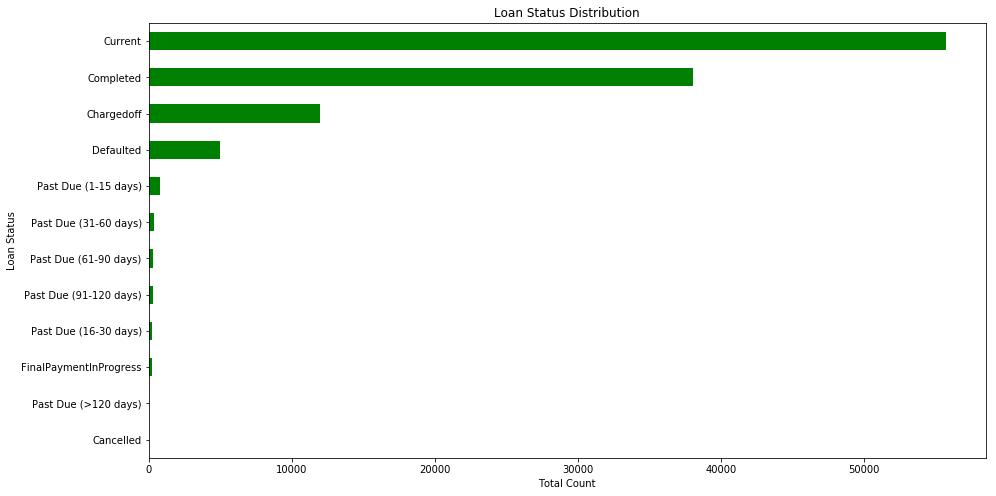

```python
from matplotlib import rcParams

rcParams['figure.figsize'] = 15, 8
status_ordered.plot(kind = 'barh', grid = False, color='g')
plt.ylabel('Loan Status')
plt.xlabel('Total Count')
plt.title('Loan Status Distribution');
```

> From the above bar chart, it can be said that although more people are still currently paying off their loans, a large number of people have also been able to completely pay of their loans.

##### Visualisation of Employment status variable

```python
loan_sub['EmploymentStatus'].value_counts(ascending = True)
```

```
Retired            795
Not employed       835
Part-time         1088
Other             3742
Not available     5347
Self-employed     6052
Full-time        26354
Employed         66598
Name: EmploymentStatus, dtype: int64
```

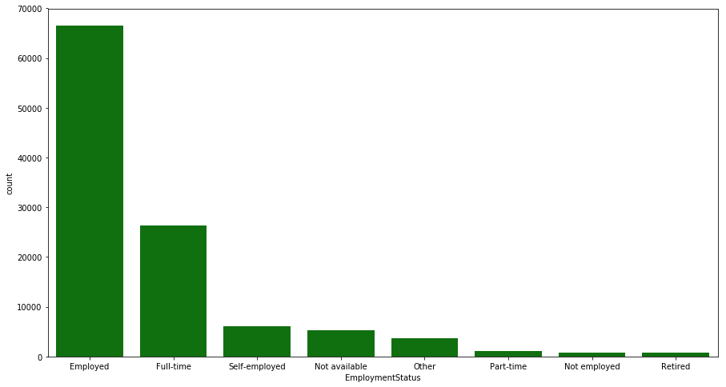

```python
freq = loan_sub['EmploymentStatus'].value_counts(ascending=False)

emp_order = freq.index

# Plot the bar chart in the decreasing order of the frequency of the 'EmploymentStatus'.
sb.countplot(data=loan_sub, x='EmploymentStatus', color='g', order=emp_order);
```

> Clearly, unemployed and retired people are the fewest to take loans.

##### Visualisation of occupation variable

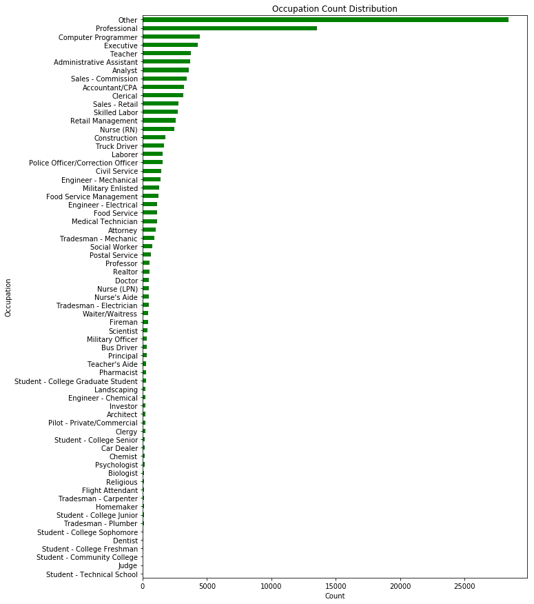

```python
occu_ordered = loan_sub.Occupation.value_counts().sort_values(ascending = True)

rcParams['figure.figsize'] = 10,15
occu_ordered.plot(kind = 'barh', grid = False, color='g')
plt.ylabel('Occupation')
plt.xlabel('Count')
plt.title('Occupation Count Distribution');
```

> A variety of different occupations opt for loans

##### Visualisation of borrower rate and borrwer APR variables

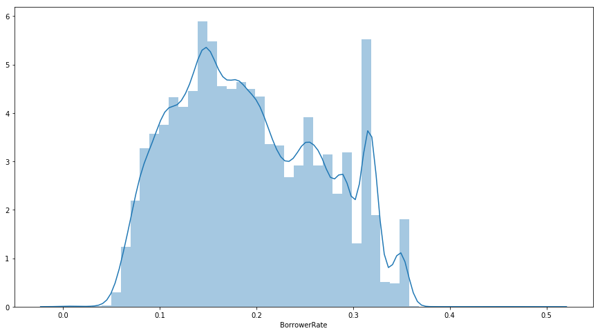

```python
plt.figure(figsize=(15,8))
sb.distplot(loan_sub['BorrowerRate']);
```

> The borrower rate histogram shows a plot skewed to the right.

###### Borrower APR

First the missing values in the borrower APR will be dropped.

```python
loan_sub.BorrowerAPR.dropna(axis = 0, inplace = True)
```

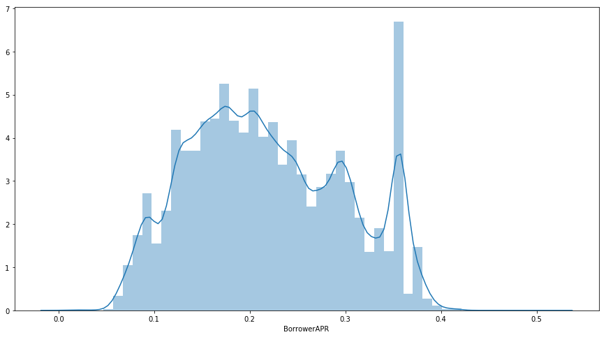

```python
plt.figure(figsize=(15,8))
sb.distplot(loan_sub['BorrowerAPR']);
```

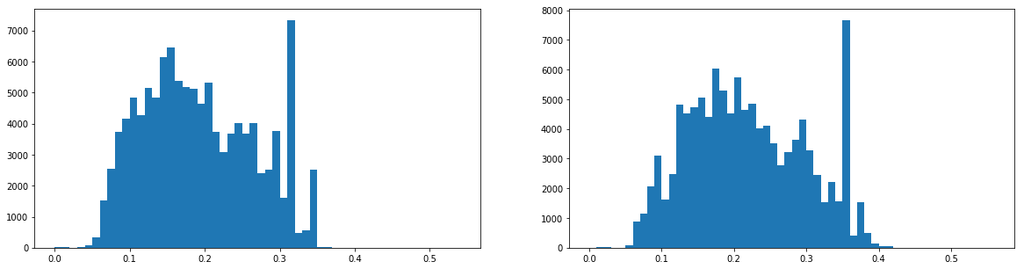

```python
#Plotting the borrower rate and borrower APR side by side
plt.figure(figsize = [20, 5])

# histogram on left
# 1 row, 2 cols, subplot 1
plt.subplot(1, 2, 1)
bins = np.arange(0, loan_sub['BorrowerRate'].max()+0.05, 0.01)
plt.hist(data = loan_sub, x = 'BorrowerRate', bins = bins);

# histogram on right
plt.subplot(1, 2, 2) # 1 row, 2 cols, subplot 2
bins = np.arange(0, loan_sub['BorrowerAPR'].max()+0.05, 0.01)
plt.hist(data = loan_sub, x = 'BorrowerAPR', bins = bins);
```

> both plots are skewed in the same direction

##### Visualisation of listing category variable

> Changing the numeric values to their categorical meanings before plotting.

```python
loan_sub['ListingCategory (numeric)'].replace({0:'Not Available', 1:'Debt Consolidation', 2:'Home Improvement',
                                              3:'Business', 4:'Personal Loan', 5:'Student Use', 6:'Auto', 7:'Other',
                                               8:'Baby&Adoption', 9:'Boat', 10:'Cosmetic Procedure', 11:'Engagement Ring',
                                               12:'Green Loans', 13:'Household Expenses', 14:'Large Purchases', 15:'Medical/Dental',
                                               16:'Motorcycle', 17:'RV', 18:'Taxes', 19:'Vacation', 20:'Wedding Loans'}, inplace=True)
```

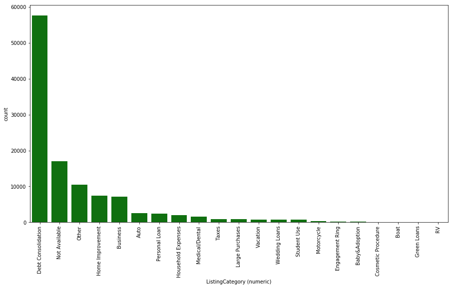

```python
list_freq = loan_sub['ListingCategory (numeric)'].value_counts(ascending=False)

list_order = list_freq.index
plt.figure(figsize=(15,8))
plt.xticks(rotation=90)
sb.countplot(data=loan_sub, x='ListingCategory (numeric)', color='g', order=list_order);
```

> Debt consolidation appears to be the major reason people get loans from the company, with RV coming in last.

##### Visualisation for IncomeRange variable

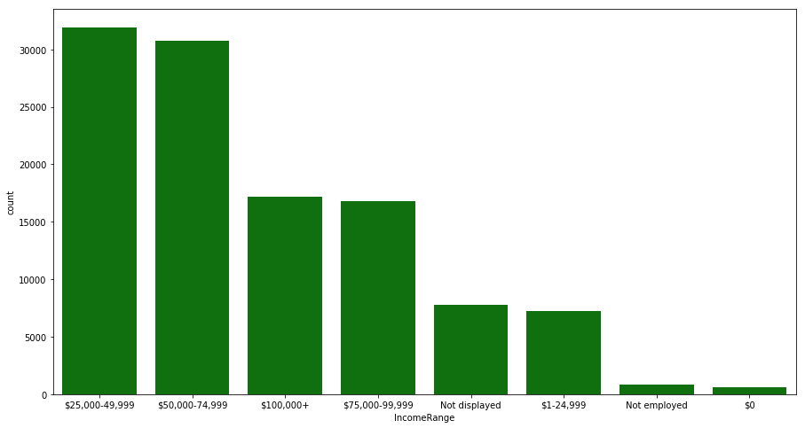

```python
income_freq = loan_sub['IncomeRange'].value_counts(ascending=False)

income_order = income_freq.index

plt.figure(figsize=(15,8))
sb.countplot(data=loan_sub, x='IncomeRange', color='g', order=income_order);
```

People within the 25,000- 49,999 salary range apply for loans more.

##### Is borrower a home owner?

```python
home_counts = loan_sub['IsBorrowerHomeowner'].value_counts()
home_counts
```

```
True     57052
False    56014
Name: IsBorrowerHomeowner, dtype: int64
```

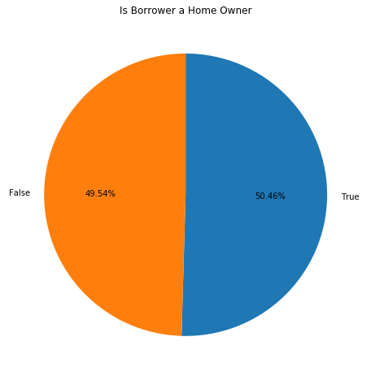

```python
plt.figure(figsize=(15,8))
plt.title('Is Borrower a Home Owner')
plt.axis('square')
plt.pie(home_counts, labels = home_counts.index, startangle = 90, counterclock = False, autopct='%.2f%%');
```

##### Visualisation for IncomeVerifiable variable

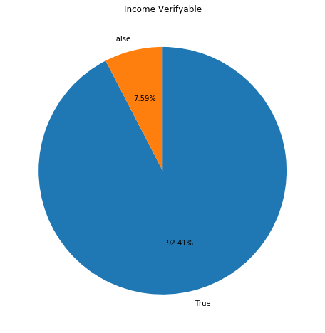

```python
ver_counts = loan_sub['IncomeVerifiable'].value_counts()
plt.figure(figsize=(15,8))
plt.title('Income Verifyable')
plt.axis('square')
plt.pie(ver_counts, labels = ver_counts.index, startangle = 90, counterclock = False, autopct='%.2f%%');
```

> More loan seakers income were verified than not.

### Discuss the distribution(s) of your variable(s) of interest. Were there any unusual points? Did you need to perform any transformations?

> Other than the missing records in the BorrowerAPR column, there were no unusual points within my selected variables.

### Of the features you investigated, were there any unusual distributions? Did you perform any operations on the data to tidy, adjust, or change the form of the data? If so, why did you do this?

> Adjustments made were:
> - Dropping the missing values in the borrower APR
> - Changing the numeric values of the Listing CAtegory variable to their categorical meanings.

## Bivariate Exploration

Visualisations will be produced to see the relationship between the Loan status and a few other variables, and also the loan original amount against some other variables.

##### Loan Status vs Employment status

In order to reduce the number of unique values present in the loan status column, the unique entries that stated 'past due' were all merged into one unique variable by splitting the values by space and taking the first part.

```python
loan_sub['LoanStatus_New'] = loan_sub['LoanStatus'].apply(lambda x:x.split()[0])
```

```python
loan_sub.head()
```

|  | ListingNumber | LoanStatus | LoanOriginationDate | EmploymentStatus | Occupation | BorrowerRate | BorrowerAPR | EmploymentStatusDuration | IncomeRange | StatedMonthlyIncome | ... | OnTimeProsperPayments | ProsperPaymentsLessThanOneMonthLate | ProsperPaymentsOneMonthPlusLate | CreditScoreRangeLower | CreditScoreRangeUpper | DebtToIncomeRatio | LoanOriginalAmount | Term | ProsperScore | LoanStatus_New |
| --- | --- | --- | --- | --- | --- | --- | --- | --- | --- | --- | --- | --- | --- | --- | --- | --- | --- | --- | --- | --- | --- |
| 0 | 193129 | Completed | 2007-09-12 | Self-employed | Other | 0.1580 | 0.16516 | 2.0 | $25,000-49,999 | 3083.333333 | ... | NaN | NaN | NaN | 640.0 | 659.0 | 0.17 | 9425 | 36 | NaN | Completed |
| 1 | 1209647 | Current | 2014-03-03 | Employed | Professional | 0.0920 | 0.12016 | 44.0 | $50,000-74,999 | 6125.000000 | ... | NaN | NaN | NaN | 680.0 | 699.0 | 0.18 | 10000 | 36 | 7.0 | Current |
| 2 | 81716 | Completed | 2007-01-17 | Not available | Other | 0.2750 | 0.28269 | NaN | Not displayed | 2083.333333 | ... | NaN | NaN | NaN | 480.0 | 499.0 | 0.06 | 3001 | 36 | NaN | Completed |
| 3 | 658116 | Current | 2012-11-01 | Employed | Skilled Labor | 0.0974 | 0.12528 | 113.0 | $25,000-49,999 | 2875.000000 | ... | NaN | NaN | NaN | 800.0 | 819.0 | 0.15 | 10000 | 36 | 9.0 | Current |
| 4 | 909464 | Current | 2013-09-20 | Employed | Executive | 0.2085 | 0.24614 | 44.0 | $100,000+ | 9583.333333 | ... | 11.0 | 0.0 | 0.0 | 680.0 | 699.0 | 0.26 | 15000 | 36 | 4.0 | Current |

5 rows × 25 columns

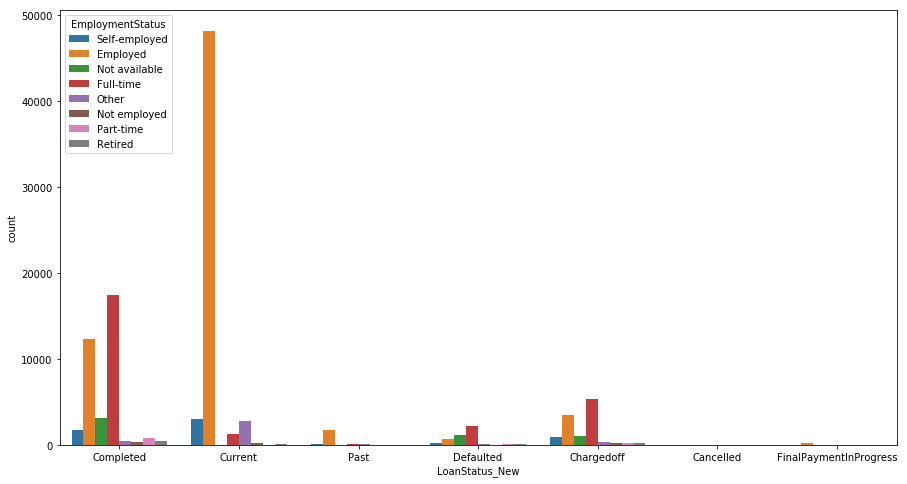

```python
plt.figure(figsize=(15,8))
sb.countplot(data = loan_sub, x = 'LoanStatus_New', hue = 'EmploymentStatus');
```

```python
ct_counts = loan_sub.groupby(['EmploymentStatus', 'LoanStatus_New']).size()
ct_counts = ct_counts.reset_index(name='count')
ct_counts = ct_counts.pivot(index = 'EmploymentStatus', columns = 'LoanStatus_New', values = 'count')
```

> Further using a heat map to plot the relationship

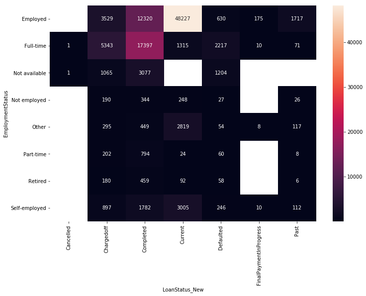

```python
plt.figure(figsize = [12, 8])
sb.heatmap(ct_counts, annot = True, fmt = '.0f')
```

##### Loan Status vs Home ownership

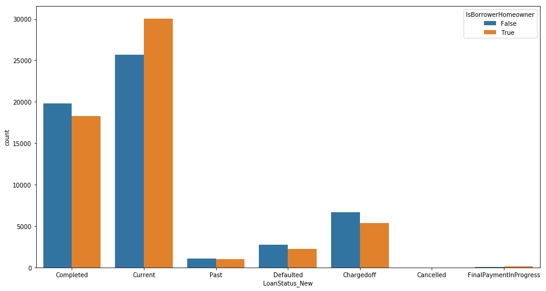

```python
plt.figure(figsize=(15,8))
sb.countplot(data = loan_sub, x = 'LoanStatus_New', hue = 'IsBorrowerHomeowner');
```

##### Loan Status vs Term

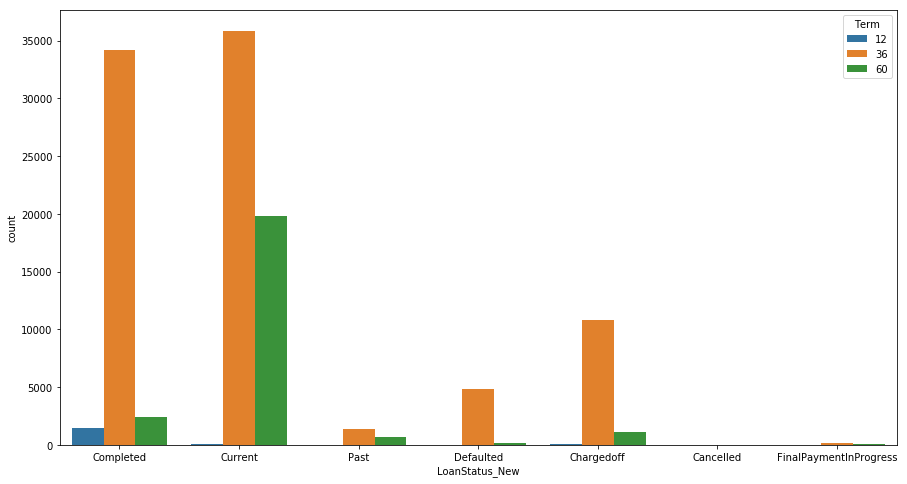

```python
plt.figure(figsize=(15,8))
sb.countplot(data = loan_sub, x = 'LoanStatus_New', hue = 'Term');
```

##### Loan Status vs Prosper Score

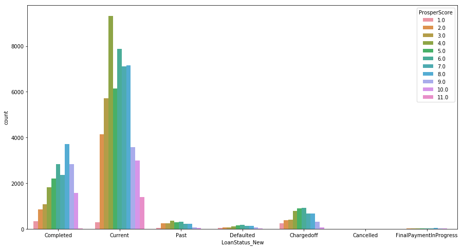

```python
plt.figure(figsize=(15,8))
sb.countplot(data = loan_sub, x = 'LoanStatus_New', hue = 'ProsperScore');
```

##### Loan Status vs Loan original amount

```
(-4250.3432023015885, 39398.526359200288)
```

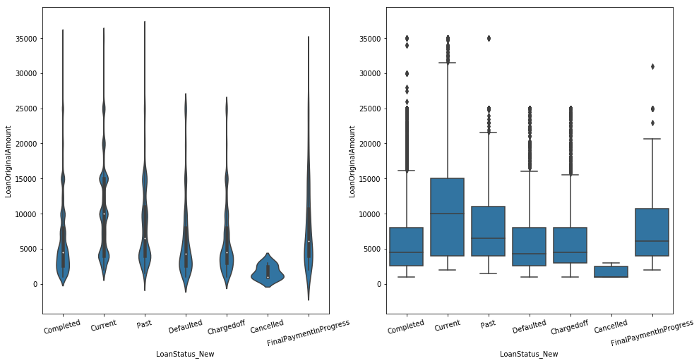

```python
plt.figure(figsize = [16, 8])
base_color = sb.color_palette()[0]

plt.subplot(1, 2, 1)
#Let's return the axes object
ax1 = sb.violinplot(data=loan_sub, x='LoanStatus_New', y='LoanOriginalAmount', color=base_color)
plt.xticks(rotation=15);

plt.subplot(1, 2, 2)
sb.boxplot(data=loan_sub, x='LoanStatus_New', y='LoanOriginalAmount', color=base_color)
plt.xticks(rotation=15);
plt.ylim(ax1.get_ylim()) # set y-axis limits to be same as left plot
```

##### Loan original amount vs Income range

```
(-4763.5179967532495, 39295.795984421507)
```

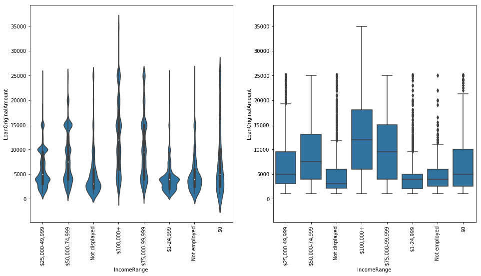

```python
plt.figure(figsize = [16, 8])
base_color = sb.color_palette()[0]

plt.subplot(1, 2, 1)
#Let's return the axes object
ax1 = sb.violinplot(data=loan_sub, x='IncomeRange', y='LoanOriginalAmount', color=base_color);
plt.xticks(rotation=90);

plt.subplot(1, 2, 2)
sb.boxplot(data=loan_sub, x='IncomeRange', y='LoanOriginalAmount', color=base_color);
plt.xticks(rotation=90);
plt.ylim(ax1.get_ylim()) # set y-axis limits to be same as left plot
```

##### Loan original amount vs borrower rate

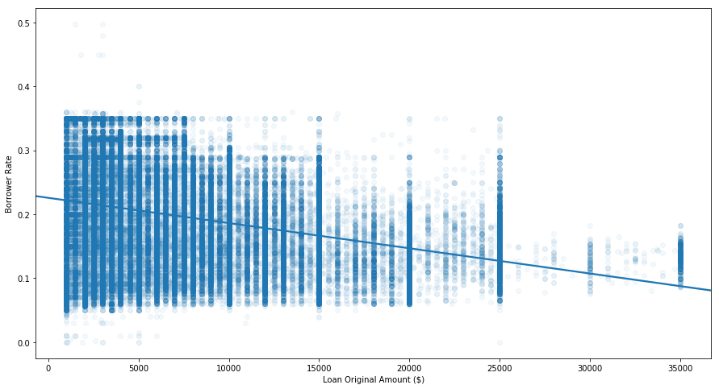

```python
plt.figure(figsize = [15, 8])
sb.regplot(data = loan_sub , x = 'LoanOriginalAmount', y = 'BorrowerRate', truncate=False, x_jitter=0.3, scatter_kws={'alpha':1/20});
plt.xlabel('Loan Original Amount ($)')
plt.ylabel('Borrower Rate');
```

##### Loan original amount vs borrower APR

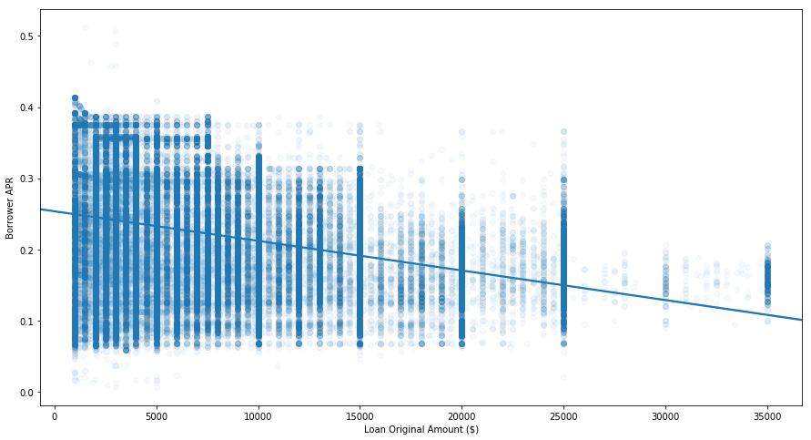

```python
plt.figure(figsize = [15, 8])
sb.regplot(data = loan_sub , x = 'LoanOriginalAmount', y = 'BorrowerAPR', truncate=False, x_jitter=0.3, scatter_kws={'alpha':1/30});
plt.xlabel('Loan Original Amount ($)')
plt.ylabel('Borrower APR');
```

### Talk about some of the relationships you observed in this part of the investigation. How did the feature(s) of interest vary with other features in the dataset?

> - The loan original amount plotted against the borrower APR and the borrower rate have similar plots. They bot have a negative regression, meaning that the higher the loan amount, the lower the rates and APR.
> - it can be seen from the loan status vs term plot that majority of the people have opted for the 36 months term for their payments and those on the 36 months term have the higher counts in all payment statuses... even the defaulted.
> - The prosper score of between 4.0 to 9.0 is where most people from both the currently paying off loan status and the completed loan statu lie. This is a good indication that the prosper score does not neccessarily affect your ability to pay back your loan.
> - The completed status has a higher number of people who do not own homes.

## Multivariate Exploration

### Correlations of variables that may hinder loan payment.

#### - Financial wise

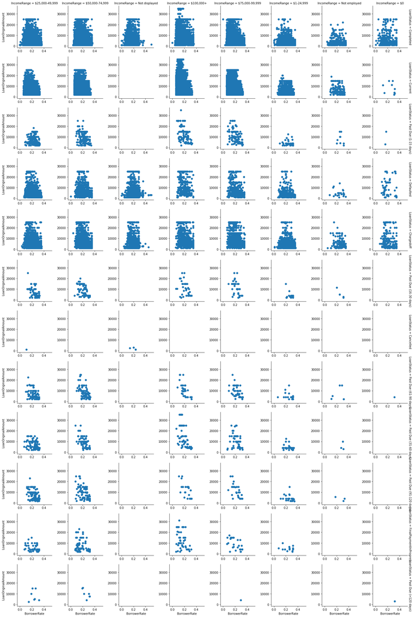

```python
g = sb.FacetGrid(data = loan_sub, col = 'IncomeRange', row = 'LoanStatus', size = 2.5,
                margin_titles = True)
g.map(plt.scatter, 'BorrowerRate', 'LoanOriginalAmount')
```

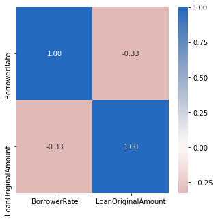

```python
# correlations of variables that may hinder loan payment
plt.figure(figsize = [5, 5])
sb.heatmap(loan_sub[['IncomeRange', 'LoanStatus', 'BorrowerRate', 'LoanOriginalAmount']]
           .corr(), annot = True, fmt = '.2f',
           cmap = 'vlag_r', center = 0)
plt.show()
```

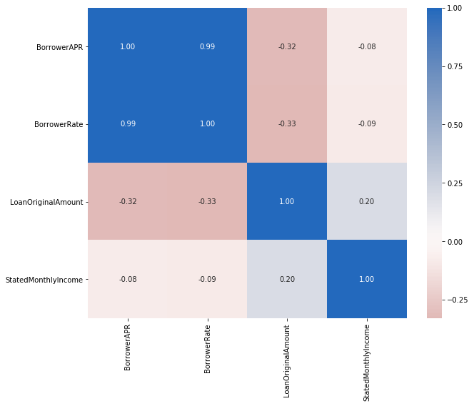

```python
# correlations
plt.figure(figsize = [10, 8])
sb.heatmap(loan_sub[['BorrowerAPR', 'BorrowerRate', 'LoanOriginalAmount', 'LoanStatus', 'IncomeRange', 'StatedMonthlyIncome']]
           .corr(), annot = True, fmt = '.2f',
           cmap = 'vlag_r', center = 0)
plt.yticks(rotation = 0)
plt.xticks(rotation = 90)
plt.show()
```

#### - Other obstacles

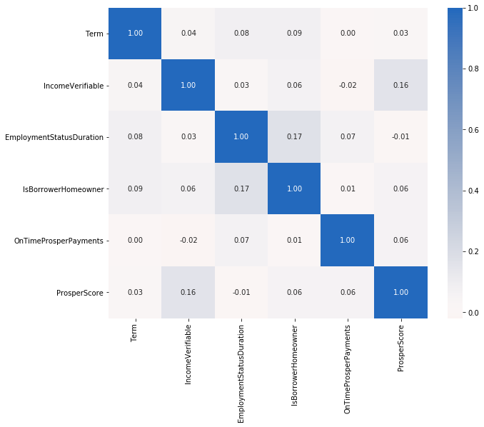

```python
# correlations of variables that may hinder loan payment
plt.figure(figsize = [10, 8])
sb.heatmap(loan_sub[['Occupation', 'Term', 'LoanStatus',
               'IncomeVerifiable', 'BorrowerState', 'EmploymentStatus', 'EmploymentStatusDuration', 'IsBorrowerHomeowner', 'OnTimeProsperPayments',
              'ProsperScore', 'ListingCategory (numeric)']]
           .corr(), annot = True, fmt = '.2f',
           cmap = 'vlag_r', center = 0)
plt.show()
```

### Correlation for the reasons people take loans

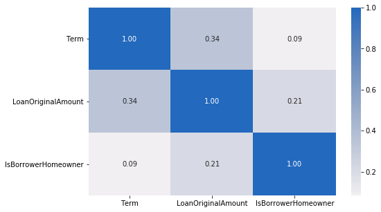

```python
# correlations
plt.figure(figsize = [8, 5])
sb.heatmap(loan_sub[['Occupation', 'Term', 'LoanOriginalAmount', 'IsBorrowerHomeowner', 'ListingCategory (numeric)']]
           .corr(), annot = True, fmt = '.2f',
           cmap = 'vlag_r', center = 0)
plt.show()
```

### Overall correlation heat map

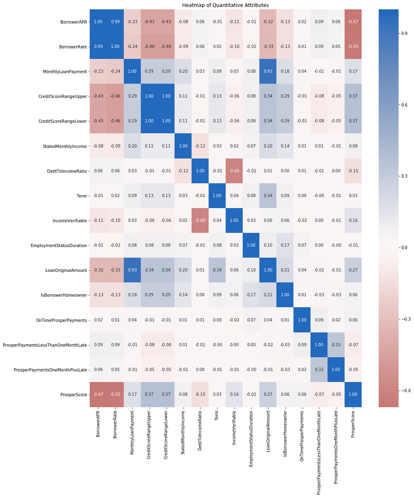

```python
# correlations
plt.figure(figsize = [15, 18])
plt.title('Heatmap of Quantitative Attributes')
sb.heatmap(loan_sub[['BorrowerAPR', 'BorrowerRate', 'MonthlyLoanPayment', 'CreditScoreRangeUpper',
               'CreditScoreRangeLower', 'StatedMonthlyIncome', 'DebtToIncomeRatio', 'Term',
               'IncomeVerifiable','EmploymentStatusDuration', 'LoanOriginalAmount',
               'IsBorrowerHomeowner', 'OnTimeProsperPayments', 'ProsperPaymentsLessThanOneMonthLate', 'ProsperPaymentsOneMonthPlusLate',
              'LoanOriginationDate', 'ProsperScore']]
           .corr(), annot = True, fmt = '.2f',
           cmap = 'vlag_r', center = 0)
plt.show()
```

### Talk about some of the relationships you observed in this part of the investigation. Were there features that strengthened each other in terms of looking at your feature(s) of interest?

> From all the multivariate charts plotted the features identidfied which streghtened each other the most were Borrowerrate and BorrowerAPR which are quite similar, so that wasn't a surprise. LaonOriginalAmount and MonthlyLoanPayment closely followed behind as the higher the original amount tallies with the higher MonthlyLoanPayment. ProsperScore against both BorowerRate and BorrowerAPR had a fair bit of negative correlation implying that for high prosper scores which meant the loanee had lower risk their rates were lower and vice versa.

### Were there any interesting or surprising interactions between features?

> I was quite surprised that EmploymentStatusDuration had no obvious correlations with any of the other loan factors, I would have expected that would have palyed into the loanee prosper scores at least but it wasn't so